# Agromorphological diversity and promising accessions of common bean (Phaseolus vulgaris) in the northeastern Peruvian Andes

```
Linear mixed model fit by REML ['lmerMod']
Formula: as ~ 1 + (1 | block) + (1 | cols) + (1 | entry)
   Data: dt.rm
Weights: weights

REML criterion at convergence: -2.9

Scaled residuals:
     Min       1Q   Median       3Q      Max
-2.29200 -0.51086 -0.06425  0.75077  1.79444

Random effects:
 Groups   Name        Variance Std.Dev.
 block    (Intercept) 0.005059 0.07112
 cols     (Intercept) 0.000000 0.00000
 entry    (Intercept) 1.101546 1.04955
 Residual             0.039491 0.19872
Number of obs: 48, groups:  block, 24; cols, 6; entry, 2

Fixed effects:
            Estimate Std. Error t value
(Intercept)   8.9790     0.7428   12.09
optimizer (nloptwrap) convergence code: 0 (OK)
boundary (singular) fit: see help('isSingular')
```

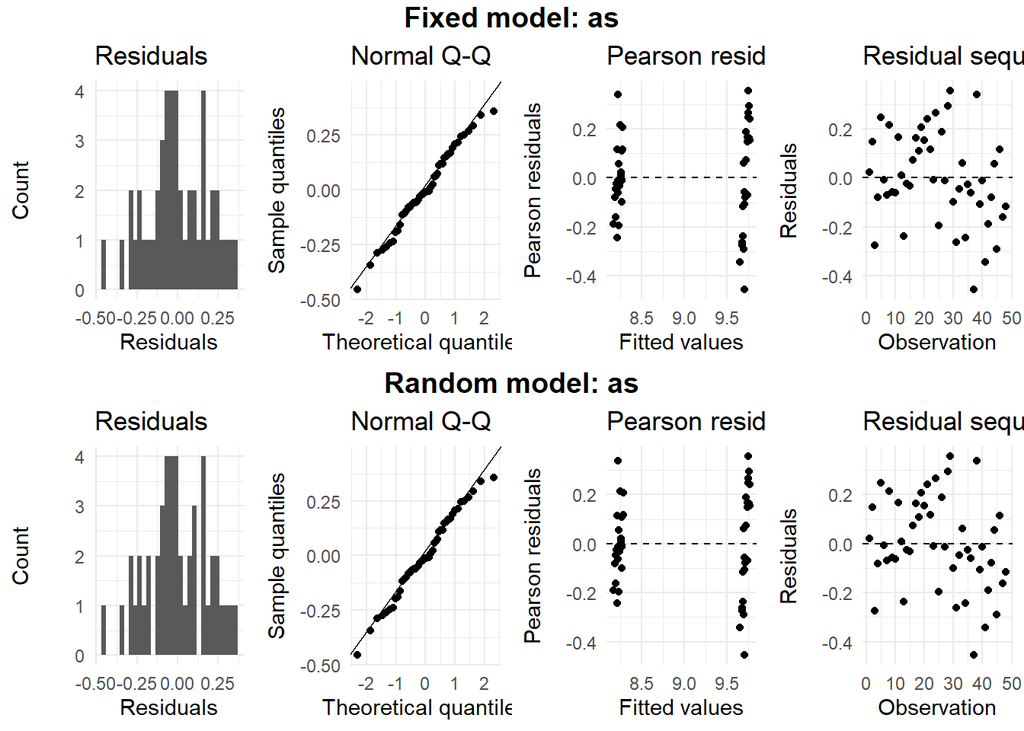

```
Linear mixed model fit by REML ['lmerMod']
Formula: rp ~ 1 + (1 | block) + (1 | cols) + (1 | entry)
   Data: dt.rm
Weights: weights

REML criterion at convergence: 503

Scaled residuals:
    Min      1Q  Median      3Q     Max
-1.5014 -0.5421 -0.2373  0.5629  2.2147

Random effects:
 Groups   Name        Variance Std.Dev.
 block    (Intercept) 1234.0   35.13
 cols     (Intercept)  183.0   13.53
 entry    (Intercept)  936.9   30.61
 Residual             1232.9   35.11
Number of obs: 48, groups:  block, 24; cols, 6; entry, 2

Fixed effects:
            Estimate Std. Error t value
(Intercept)   146.23      24.02   6.088
```

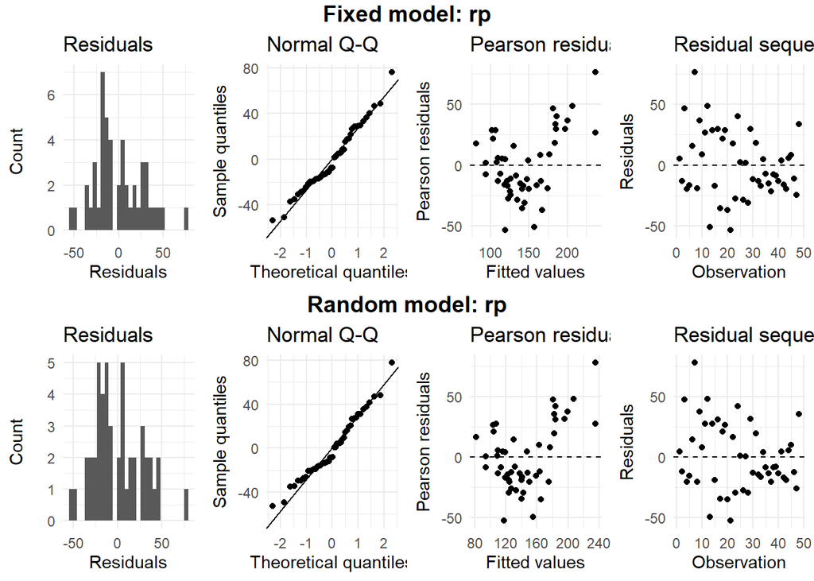

```
Linear mixed model fit by REML ['lmerMod']
Formula: hc ~ 1 + (1 | block) + (1 | cols) + (1 | entry)
   Data: dt.rm
Weights: weights

REML criterion at convergence: 300.6

Scaled residuals:
     Min       1Q   Median       3Q      Max
-1.50286 -0.59379 -0.06698  0.47478  1.71564

Random effects:
 Groups   Name        Variance Std.Dev.
 block    (Intercept) 10.341   3.216
 cols     (Intercept)  3.638   1.907
 entry    (Intercept)  4.651   2.157
 Residual             20.415   4.518
Number of obs: 48, groups:  block, 24; cols, 6; entry, 2

Fixed effects:
            Estimate Std. Error t value
(Intercept)    41.88       1.95   21.47
```

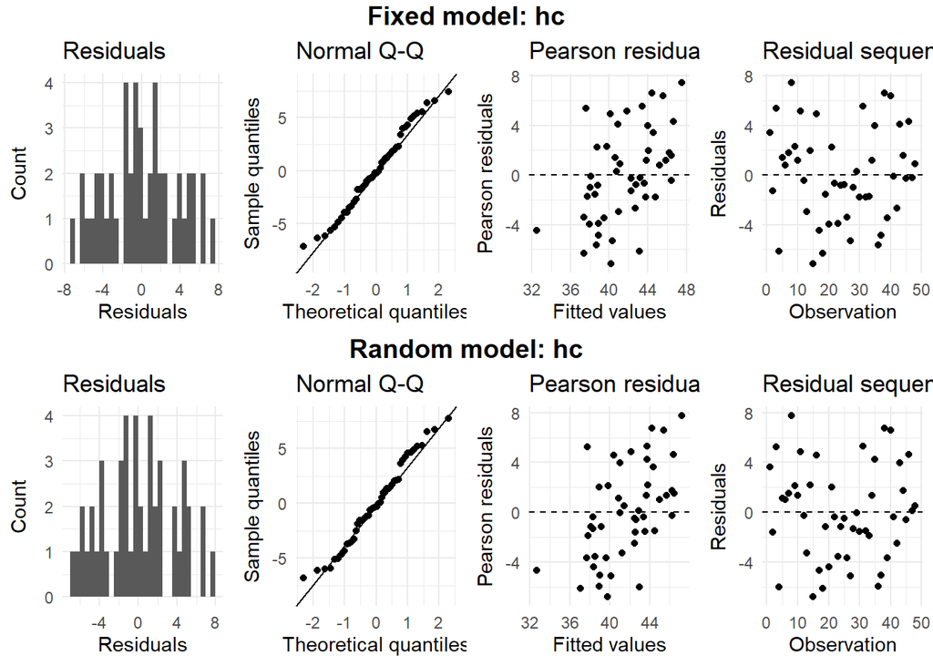

| trait | rep | geno | env | year | mean | std | min | max | V.g | V.e | V.p | repeatability | H2.s | H2.p | H2.c |
| --- | --- | --- | --- | --- | --- | --- | --- | --- | --- | --- | --- | --- | --- | --- | --- |
| ap50f | 24 | 2 | 1 | 1 | 79.46 | 75.78 | 25.88 | 133.04 | 5737 | 127.77 | 5742.32 | 1 | 1 | 1 | 1 |
| ap50m | 24 | 2 | 1 | 1 | 141.25 | 149.55 | 35.5 | 247 | 22363.04 | 194.62 | 22371.14 | 1 | 1 | 1 | 1 |
| dt | 24 | 2 | 1 | 1 | 8.18 | 0.62 | 7.74 | 8.61 | 0.37 | 0.26 | 0.38 | 0.97 | 0.97 | 0.98 | 0.95 |
| spad | 24 | 2 | 1 | 1 | 46.51 | 2.69 | 44.61 | 48.42 | 6.39 | 20.23 | 7.24 | 0.88 | 0.88 | 0.94 | 0.88 |
| nrfp | 24 | 2 | 1 | 1 | 8.15 | 1.74 | 6.92 | 9.38 | 2.95 | 1.83 | 3.02 | 0.97 | 0.97 | 0.98 | 0.96 |
| df | 24 | 2 | 1 | 1 | 74.77 | 10.99 | 67 | 82.54 | 120.74 | 0.78 | 120.77 | 1 | 1 | 1 | 1 |
| dflo | 24 | 2 | 1 | 1 | 16.38 | 6.19 | 12 | 20.75 | 38.22 | 1.53 | 38.29 | 1 | 1 | 1 | 1 |
| lv | 24 | 2 | 1 | 1 | 14.83 | 4.45 | 11.68 | 17.98 | 19.82 | 0.57 | 19.84 | 1 | 1 | 1 | 1 |
| vp | 24 | 2 | 1 | 1 | 55.42 | 15.38 | 44.54 | 66.29 | 232.41 | 99.66 | 236.56 | 0.98 | 0.98 | 0.99 | 0.98 |
| dhm | 24 | 2 | 1 | 1 | 176.78 | 42.82 | 146.5 | 207.05 | 1832.63 | 15.05 | 1833.25 | 1 | 1 | 1 | 1 |

[output cut: 7 more lines]

## 4.2 BLUEs of accessions and checks

## 4.3 Principal component and cluster analyses based on BLUEs

### 4.3.1 Adjusted genotypic means (BLUEs) used for multivariate analysis

| geno | PH50F | PH90M | SD | SPAD | NFC | D50F | FD | PL | NPP | D90M | NSP | PW | SW | SL | SWd | YP | HI |
| --- | --- | --- | --- | --- | --- | --- | --- | --- | --- | --- | --- | --- | --- | --- | --- | --- | --- |
| 1001 | 123.38 | 210.77 | 7.77 | 40.4 | 4.84 | 86 | 16 | 13.27 | 41.17 | 175.91 | 6 | 15.67 | 98.85 | 16.28 | 8.05 | 275.14 | 80.07 |
| 1003 | 138.45 | 201.67 | 8.03 | 50.2 | 7.38 | 82 | 18 | 15.28 | 127.33 | 176.04 | 7 | 14.87 | 93.31 | 14.01 | 8.71 | 450.62 | 30.84 |
| 1004 | 164.59 | 234.26 | 9.8 | 53.28 | 17.38 | 83 | 18 | 13.31 | 131.96 | 175.83 | 7 | 13.27 | 66.89 | 11.36 | 8.62 | 482.74 | 47.39 |
| 1005 | 158.6 | 228.96 | 7.63 | 44.94 | 10.53 | 79 | 20 | 15.24 | 53.04 | 176.25 | 5 | 14.72 | 61.55 | 13.49 | 6.95 | 152.29 | 53.84 |
| 1006 | 46.96 | 162.49 | 10.2 | 49.26 | 10.69 | 79 | 18 | 15.49 | 39.54 | 172.25 | 5 | 12.16 | 78.82 | 16.83 | 6.44 | 91.21 | 25.68 |
| 1007 | 79.98 | 99.86 | 10.3 | 48.38 | 13.07 | 74 | 25 | 15.97 | 78.13 | 162.25 | 6 | 10.45 | 62.73 | 12.2 | 7.88 | 307.84 | 58.98 |
| 1009 | 135.38 | 220.77 | 8.63 | 45.89 | 7.84 | 83 | 20 | 12.26 | 25.17 | 196.25 | 5 | 15.67 | 126.83 | 14.3 | 10.29 | 88.95 | 48.09 |
| 1012 | 149.96 | 237.49 | 9.77 | 54.77 | 7.69 | 83 | 20 | 13.79 | 76.54 | 183.84 | 5 | 13.96 | 110.73 | 13.35 | 9.61 | 294.13 | 46.33 |
| 1014 | 131.45 | 211.67 | 7.33 | 55.83 | 5.38 | 86 | 17 | 15.5 | 49.33 | 178.84 | 6 | 15.54 | 107.75 | 13.2 | 9.69 | 174.39 | 35.28 |
| 1015 | 122.59 | 184.98 | 7.23 | 49.91 | 8.3 | 83 | 16 | 10.64 | 93.09 | 172.04 | 7 | 13.09 | 85.99 | 18.09 | 6.71 | 271.66 | 39 |

[output cut: 70 more lines]

### 4.3.2 Multivariate Analysis using BLUEs

```
Principal Component Analysis Results for variables
 ===================================================
  Name       Description
1 "$coord"   "Coordinates for the variables"
2 "$cor"     "Correlations between variables and dimensions"
3 "$cos2"    "Cos2 for the variables"
4 "$contrib" "contributions of the variables"
```

Variable correlations

|  | Dim.1 | Dim.2 | Dim.3 | Dim.4 | Dim.5 |
| --- | --- | --- | --- | --- | --- |
| PH50F | 0.4357790 | 0.3713848 | -0.5924432 | 0.4008843 | -0.1478132 |
| PH90M | 0.5650291 | 0.5161911 | -0.4014647 | 0.2741210 | 0.0204220 |
| SD | 0.8389928 | -0.2222642 | 0.0595796 | -0.1185445 | -0.0201003 |
| SPAD | -0.2803847 | -0.0362371 | -0.0516049 | -0.2230205 | 0.8249000 |
| NFC | 0.7693660 | -0.3150705 | 0.0206279 | 0.1344154 | -0.1050534 |
| D50F | 0.7543629 | -0.2042090 | 0.0804208 | -0.0719548 | -0.0953117 |
| FD | 0.7248838 | -0.2450280 | -0.2124403 | 0.1484895 | 0.0817857 |
| PL | -0.3398618 | 0.7581517 | 0.1439425 | 0.0939167 | -0.0980826 |
| NPP | 0.7303676 | 0.0827116 | 0.4321106 | 0.3151717 | 0.2356441 |
| D90M | 0.9072592 | 0.0327223 | 0.0722498 | -0.0413852 | 0.0679516 |
| NSP | -0.6407393 | 0.4986020 | 0.0698398 | 0.3562674 | 0.0139402 |
| PW | 0.8037451 | 0.2500082 | -0.0805246 | -0.0674291 | 0.0254027 |
| SW | 0.2635749 | 0.8512279 | 0.0363567 | -0.3810735 | -0.0450150 |
| SL | 0.2606275 | 0.5155675 | 0.4565353 | -0.3917380 | -0.3569456 |
| SWd | 0.1123257 | 0.7172869 | -0.3434354 | -0.2464199 | 0.2675285 |
| YP | 0.4908984 | 0.3777003 | 0.5681049 | 0.3858700 | 0.2995252 |
| HI | -0.5478358 | 0.0761785 | 0.1708841 | 0.5236765 | -0.0797661 |

Variable contribution

|  | Dim.1 | Dim.2 | Dim.3 | Dim.4 | Dim.5 |
| --- | --- | --- | --- | --- | --- |
| PH50F | 3.0640118 | 4.3057981 | 23.8110490 | 11.7407597 | 1.9905369 |
| PH90M | 5.1510948 | 8.3181436 | 10.9340191 | 5.4896236 | 0.0379964 |
| SD | 11.3572799 | 1.5422128 | 0.2408134 | 1.0266461 | 0.0368084 |
| SPAD | 1.2684298 | 0.0409933 | 0.1806624 | 3.6336890 | 61.9935354 |
| NFC | 9.5504487 | 3.0989950 | 0.0288665 | 1.3199455 | 1.0054582 |
| D50F | 9.1816021 | 1.3018324 | 0.4387543 | 0.3782492 | 0.8276292 |
| FD | 8.4780229 | 1.8742895 | 3.0616732 | 1.6108290 | 0.6093941 |
| PL | 1.8636418 | 17.9439337 | 1.4056042 | 0.6443823 | 0.8764520 |
| NPP | 8.6067833 | 0.2135690 | 12.6670346 | 7.2569226 | 5.0589085 |
| D90M | 13.2806904 | 0.0334266 | 0.3541260 | 0.1251260 | 0.4206717 |
| NSP | 6.6240039 | 7.7609232 | 0.3308953 | 9.2727827 | 0.0177044 |
| PW | 10.4230430 | 1.9512549 | 0.4398880 | 0.3321646 | 0.0587901 |
| SW | 1.1208975 | 22.6202341 | 0.0896714 | 10.6090240 | 0.1846111 |
| SL | 1.0959695 | 8.2980585 | 14.1394922 | 11.2111317 | 11.6077448 |
| SWd | 0.2035711 | 16.0616872 | 8.0015698 | 4.4361841 | 6.5205450 |
| YP | 3.8881322 | 4.4534847 | 21.8948631 | 10.8777760 | 8.1735444 |
| HI | 4.8423773 | 0.1811633 | 1.9810176 | 20.0347638 | 0.5796693 |

Variable cos2

|  | Dim.1 | Dim.2 | Dim.3 | Dim.4 | Dim.5 |
| --- | --- | --- | --- | --- | --- |
| PH50F | 0.1899033 | 0.1379267 | 0.3509889 | 0.1607083 | 0.0218487 |
| PH90M | 0.3192579 | 0.2664533 | 0.1611739 | 0.0751423 | 0.0004171 |
| SD | 0.7039089 | 0.0494014 | 0.0035497 | 0.0140528 | 0.0004040 |
| SPAD | 0.0786156 | 0.0013131 | 0.0026631 | 0.0497382 | 0.6804600 |
| NFC | 0.5919240 | 0.0992694 | 0.0004255 | 0.0180675 | 0.0110362 |
| D50F | 0.5690634 | 0.0417013 | 0.0064675 | 0.0051775 | 0.0090843 |
| FD | 0.5254565 | 0.0600387 | 0.0451309 | 0.0220491 | 0.0066889 |
| PL | 0.1155060 | 0.5747941 | 0.0207194 | 0.0088203 | 0.0096202 |
| NPP | 0.5334369 | 0.0068412 | 0.1867196 | 0.0993332 | 0.0555281 |
| D90M | 0.8231193 | 0.0010707 | 0.0052200 | 0.0017127 | 0.0046174 |
| NSP | 0.4105469 | 0.2486039 | 0.0048776 | 0.1269264 | 0.0001943 |
| PW | 0.6460062 | 0.0625041 | 0.0064842 | 0.0045467 | 0.0006453 |
| SW | 0.0694717 | 0.7245890 | 0.0013218 | 0.1452170 | 0.0020263 |
| SL | 0.0679267 | 0.2658099 | 0.2084245 | 0.1534587 | 0.1274102 |
| SWd | 0.0126171 | 0.5145005 | 0.1179479 | 0.0607228 | 0.0715715 |
| YP | 0.2409812 | 0.1426575 | 0.3227432 | 0.1488957 | 0.0897153 |
| HI | 0.3001240 | 0.0058032 | 0.0292014 | 0.2742371 | 0.0063626 |

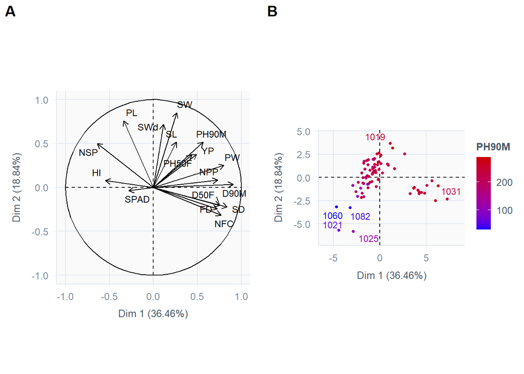

### 4.3.3 Cluster validation

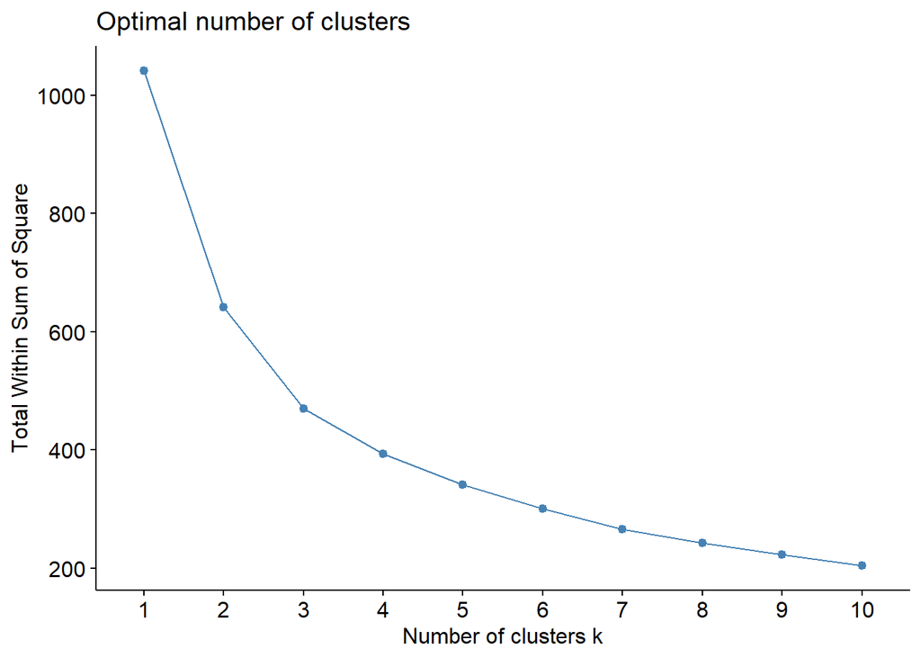

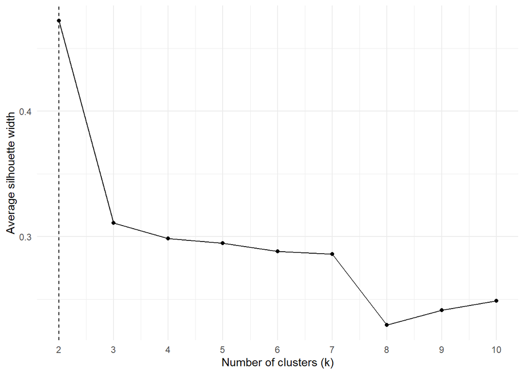

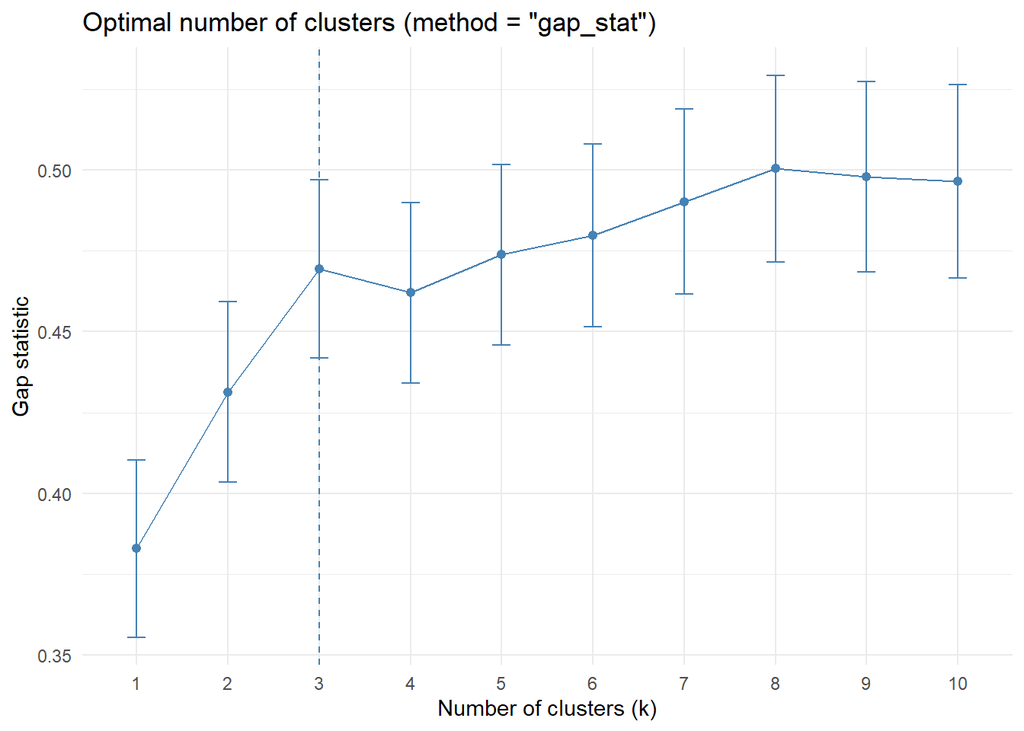

Cluster sizes obtained with HCPC

| Cluster | N |
| --- | --- |
| 1 | 26 |
| 2 | 39 |
| 3 | 13 |

Silhouette statistics for the HCPC partition

| Cluster | N | avg_sil |
| --- | --- | --- |
| 1 | 26 | 0.136 |
| 2 | 39 | 0.390 |
| 3 | 13 | 0.477 |
| Overall | 78 | 0.320 |

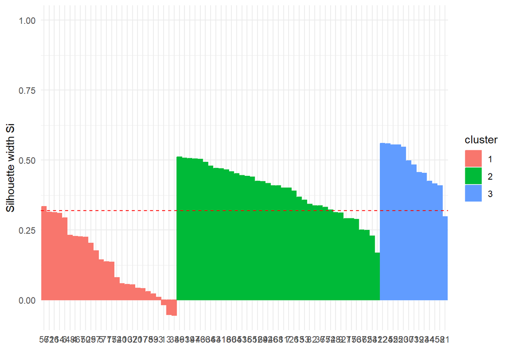

Comparison of clustering criteria and HCPC

| Method | Selected_k |
| --- | --- |
| WSS / Elbow | 3 |
| Silhouette | 2 |
| Gap statistic (global maximum) | 8 |
| Gap statistic (firstmax) | 3 |
| Gap statistic (firstSEmax) | 3 |
| Gap statistic (Tibshirani 2001) | 3 |
| HCPC | 3 |

Average silhouette width for k = 2–10

| k | avg_sil |
| --- | --- |
| 2 | 0.472 |
| 3 | 0.311 |
| 4 | 0.298 |
| 5 | 0.295 |
| 6 | 0.288 |
| 7 | 0.286 |
| 8 | 0.229 |
| 9 | 0.241 |
| 10 | 0.249 |

### 4.3.4 Multivariate clustering of 78 common bean genotypes based on BLUEs

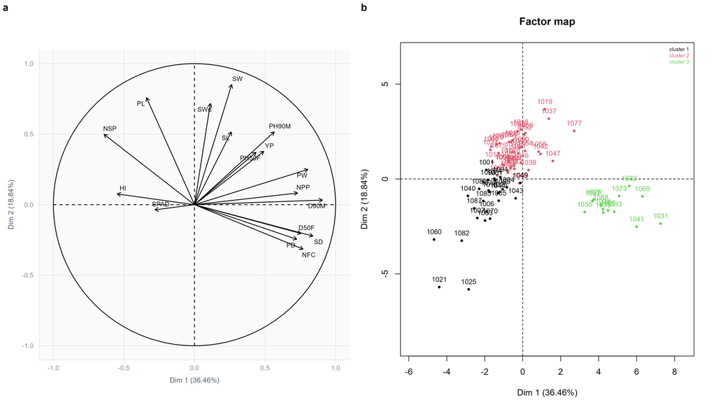

### 4.3.5 MANOVA of the clusters on PC1–PC3

```
          Df      Wilks approx F num Df den Df
Cluster    2 0.04666902 88.30528      6    146
Residuals 75         NA       NA     NA     NA
                                                          Pr(>F)
Cluster   0.0000000000000000000000000000000000000000000004514828
Residuals                                                     NA
```

```
 Response Dim.1 :
            Df Sum Sq Mean Sq F value                Pr(>F)
Cluster      2 405.59 202.795  195.39 < 0.00000000000000022 ***
Residuals   75  77.84   1.038
---
Signif. codes:  0 '***' 0.001 '**' 0.01 '*' 0.05 '.' 0.1 ' ' 1

 Response Dim.2 :
            Df Sum Sq Mean Sq F value                Pr(>F)
Cluster      2 154.18  77.088  60.426 0.0000000000000002331 ***
Residuals   75  95.68   1.276
---
Signif. codes:  0 '***' 0.001 '**' 0.01 '*' 0.05 '.' 0.1 ' ' 1

 Response Dim.3 :
            Df  Sum Sq Mean Sq F value Pr(>F)
Cluster      2   0.909 0.45464  0.2989 0.7425
Residuals   75 114.067 1.52090
```

### 4.3.6 Bootstrap support with pvclust

```
Bootstrap (r = 0.4)... Done.
Bootstrap (r = 0.6)... Done.
Bootstrap (r = 0.8)... Done.
Bootstrap (r = 1.0)... Done.
Bootstrap (r = 1.2)... Done.
Bootstrap (r = 1.4)... Done.
```

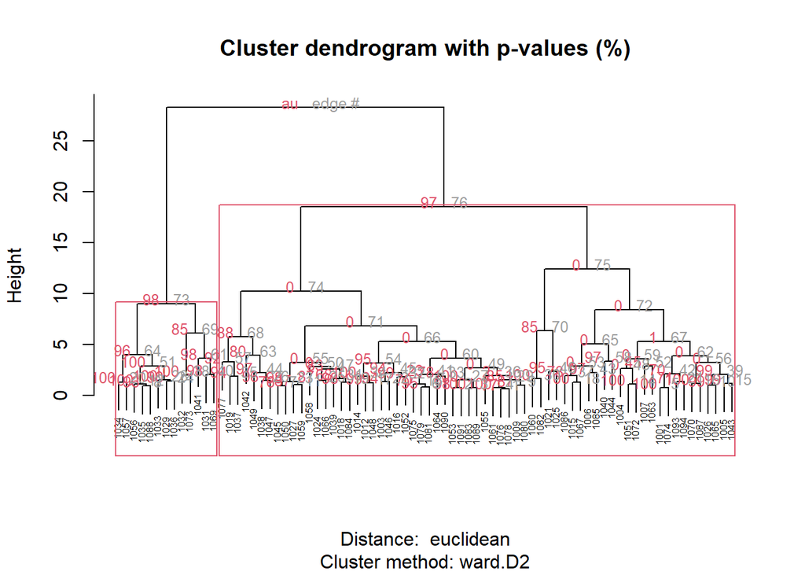

```
   HCPC
cl3  1  2  3
  1 25  1  0
  2  1 38  0
  3  0  0 13
```

| si | au | bp | se.si | se.au | se.bp | v | c | pchi |
| --- | --- | --- | --- | --- | --- | --- | --- | --- |
| 0.26 | 0.77 | 0.4 | 0.05 | 0.02 | 0.01 | -0.24 | 0.49 | 0.74 |
| 0.79 | 0.98 | 0.28 | 0.03 | 0 | 0.01 | -0.73 | 1.32 | 0 |
| 0.95 | 1 | 0.21 | 0.02 | 0 | 0.01 | -1.08 | 1.88 | 0.01 |
| 0.98 | 1 | 0.15 | 0.01 | 0 | 0.01 | -1.22 | 2.26 | 0 |
| 0.99 | 1 | 0.63 | 0 | 0 | 0.01 | -1.83 | 1.5 | 0.3 |
| 0.64 | 0.95 | 0.29 | 0.04 | 0.01 | 0.01 | -0.56 | 1.11 | 0 |
| 0.2 | 0.76 | 0.37 | 0.05 | 0.02 | 0.01 | -0.19 | 0.51 | 0.01 |
| 0.63 | 0.96 | 0.25 | 0.07 | 0.01 | 0.01 | -0.52 | 1.2 | 0.18 |
| 0 | 0.87 | 0.11 | 0 | 0.04 | 0 | 0.06 | 1.18 | 0.13 |
| 0.9 | 0.99 | 0.4 | 0.02 | 0 | 0.01 | -1.04 | 1.29 | 0 |

[output cut: 67 more lines]

### 4.3.7 PCA of accessions and checks

```
1023 1095
   1    2
```

```
# A tibble: 3 × 6
  Cluster    YP    HI  D50F  D90M    PW
    <int> <dbl> <dbl> <dbl> <dbl> <dbl>
1       1  171.  50.1  79.2  173.  13.3
2       2  338.  42.2  83.7  192.  15.9
3       3  384.  26.8 117.   230.  20.4
```

```
  geno       YP       HI     D50F     D90M       PW
1 1023 123.9870 43.54493 67.00000 146.5001 12.28750
2 1095 168.6171 40.19051 82.54167 207.0540 15.96083
```

```
[1] 0.1794872 0.2820513
```

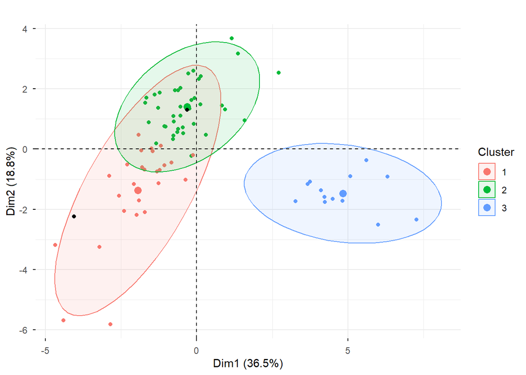

Local-market controls (BLUEs) vs. accessions

| geno | YP | HI | D50F | D90M | PW | Cluster | % accessions above YP |
| --- | --- | --- | --- | --- | --- | --- | --- |
| 1023 | 124.0 | 43.5 | 67.0 | 146.5 | 12.3 | 1 | 82.1 |
| 1095 | 168.6 | 40.2 | 82.5 | 207.1 | 16.0 | 2 | 71.8 |

### 4.3.8 Correlations among traits

Spearman correlations among the 17 BLUE traits: 136 pairwise tests. p-values were adjusted with the Benjamini–Hochberg FDR procedure (q-values); 95% CIs of rho come from a bootstrap of accessions.

| Trait1 | Trait2 | rho | p | q | rho_lo | rho_hi |
| --- | --- | --- | --- | --- | --- | --- |
| NPP | YP | 0.84 | 0 | 0 | 0.73 | 0.91 |
| SW | SWd | 0.73 | 0 | 0 | 0.61 | 0.81 |
| D90M | PW | 0.73 | 0 | 0 | 0.57 | 0.84 |
| D50F | D90M | 0.71 | 0 | 0 | 0.54 | 0.82 |
| SD | PW | 0.68 | 0 | 0 | 0.51 | 0.8 |
| SD | D90M | 0.67 | 0 | 0 | 0.49 | 0.8 |
| SD | D50F | 0.62 | 0 | 0 | 0.42 | 0.77 |
| SD | NPP | 0.6 | 0 | 0 | 0.42 | 0.74 |
| NPP | D90M | 0.58 | 0 | 0 | 0.39 | 0.74 |
| NPP | PW | 0.57 | 0 | 0 | 0.4 | 0.72 |

[output cut: 126 more lines]

```
# A tibble: 1 × 4
  total sig_p sig_q  lost
  <int> <int> <int> <int>
1   136    82    78     4
```

| Trait1 | Trait2 | rho | p | q | rho_lo | rho_hi |
| --- | --- | --- | --- | --- | --- | --- |
| SL | HI | -0.24 | 0.03 | 0.06 | -0.44 | -0.03 |
| PL | YP | 0.23 | 0.04 | 0.07 | 0 | 0.45 |
| NPP | SW | 0.23 | 0.04 | 0.07 | -0.02 | 0.46 |
| SPAD | PW | -0.23 | 0.05 | 0.08 | -0.45 | 0 |

```
Of the 136 pairwise Spearman correlations, 82 were significant at p < 0.05 (unadjusted); after Benjamini-Hochberg FDR correction, 78 remained significant (q < 0.05) and 4 lost significance.
```

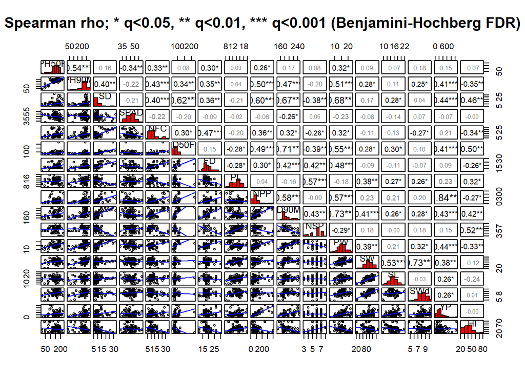

## 4.4 Tabla 2: Presents descriptive statistics for the quantitative traits evaluated in the blues dataset. For each trait, the table reports the mean, minimum, maximum, coefficient of variation (CV%) and broad-sense heritability (H²), providing a summary of the central tendency, range, relative variability and genetic determination of the measured characteristics.

```
# A tibble: 0 × 2
# ℹ 2 variables: trait <chr>, n_negative_BLUEs <int>
```

| Quantitative trait | Mean | Min | Max | CV(%) | H2 |
| --- | --- | --- | --- | --- | --- |
| PH50F | 145.12 | 14.12 | 226.38 | 29.78 | 0.60 |
| PH90M | 212.57 | 31.22 | 288.69 | 23.98 | 0.00 |
| SD | 10.72 | 5.63 | 32.37 | 51.10 | 0.94 |
| SPAD | 45.33 | 32.92 | 58.86 | 11.20 | 0.38 |
| NFC | 13.17 | 3.61 | 33.53 | 51.98 | 0.95 |
| D50F | 87.71 | 67.00 | 220.00 | 21.39 | 1.00 |
| FD | 18.86 | 12.00 | 30.00 | 17.94 | 0.00 |
| PL | 13.80 | 7.71 | 19.84 | 18.63 | 0.00 |
| NPP | 96.27 | 10.82 | 397.23 | 78.89 | 0.98 |
| D90M | 191.63 | 148.12 | 247.12 | 12.08 | 0.00 |

[output cut: 7 more lines]

## 4.5 Supplementary material

### 4.5.1 Figure 1: The figure shows a principal component analysis (PCA), where (a) displays the correlation between variables and components, (b) the percentage of variance explained by each dimension, and (c–e) the variables contributing most to dimensions 1, 2 and 3, allowing identification of the most influential variables in the data structure.

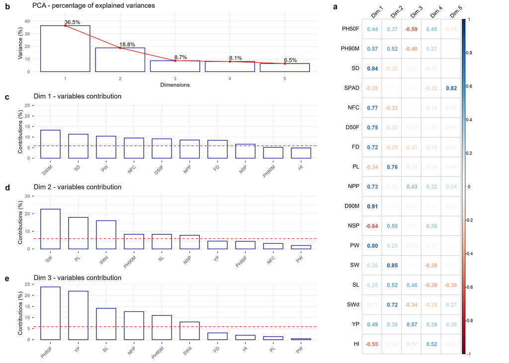

### 4.5.2 Interpretation of PC3

Eigenvalues and explained variance

|  | Eigenvalue | Variance (%) | Cumulative (%) |
| --- | --- | --- | --- |
| comp 1 | 6.20 | 36.46 | 36.46 |
| comp 2 | 3.20 | 18.84 | 55.30 |
| comp 3 | 1.47 | 8.67 | 63.97 |
| comp 4 | 1.37 | 8.05 | 72.02 |

```
Uniform contribution threshold = 5.88 %
```

Variable loadings (correlation with PC) and contribution to PC3

| Trait | Loading_PC1 | Loading_PC2 | Loading_PC3 | Contrib_PC3 | Cos2_PC3 |
| --- | --- | --- | --- | --- | --- |
| PH50F | 0.44 | 0.37 | -0.59 | 23.81 | 0.35 |
| YP | 0.49 | 0.38 | 0.57 | 21.89 | 0.32 |
| SL | 0.26 | 0.52 | 0.46 | 14.14 | 0.21 |
| NPP | 0.73 | 0.08 | 0.43 | 12.67 | 0.19 |
| PH90M | 0.57 | 0.52 | -0.40 | 10.93 | 0.16 |
| SWd | 0.11 | 0.72 | -0.34 | 8.00 | 0.12 |
| FD | 0.72 | -0.25 | -0.21 | 3.06 | 0.05 |
| HI | -0.55 | 0.08 | 0.17 | 1.98 | 0.03 |
| PL | -0.34 | 0.76 | 0.14 | 1.41 | 0.02 |
| PW | 0.80 | 0.25 | -0.08 | 0.44 | 0.01 |
| D50F | 0.75 | -0.20 | 0.08 | 0.44 | 0.01 |
| D90M | 0.91 | 0.03 | 0.07 | 0.35 | 0.01 |
| NSP | -0.64 | 0.50 | 0.07 | 0.33 | 0.00 |
| SD | 0.84 | -0.22 | 0.06 | 0.24 | 0.00 |
| SPAD | -0.28 | -0.04 | -0.05 | 0.18 | 0.00 |
| SW | 0.26 | 0.85 | 0.04 | 0.09 | 0.00 |
| NFC | 0.77 | -0.32 | 0.02 | 0.03 | 0.00 |

```
Traits contributing above the uniform threshold to PC3:
```

```
# A tibble: 6 × 3
  Trait Loading_PC3 Contrib_PC3
  <chr>       <dbl>       <dbl>
1 PH50F      -0.592       23.8
2 YP          0.568       21.9
3 SL          0.457       14.1
4 NPP         0.432       12.7
5 PH90M      -0.401       10.9
6 SWd        -0.343        8.00
```

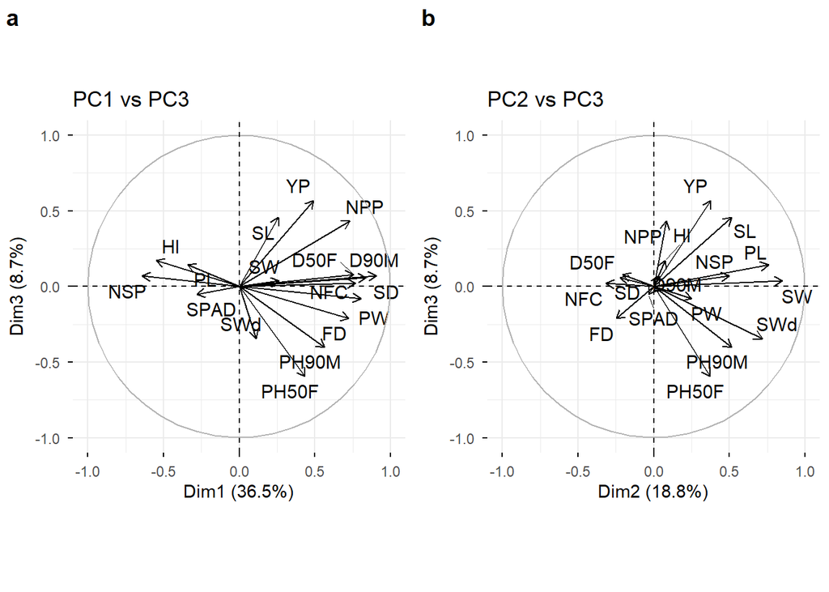

## 4.6 Tabla sumplemetaria 1

```
# A tibble: 0 × 2
# ℹ 2 variables: name <chr>, value <chr>
```

```
[1] TRUE
```

```
 [1] "geno" "ECC"  "GH"   "PP"   "PC"   "PCO"  "PC90" "LP"   "DPC"  "SS"
[11] "WPC"  "SPC"  "SCP"  "DSC"  "LSC"
```

```
character(0)
```

```
character(0)
```

```
 [1] "geno"  "PH50F" "PH90M" "SD"    "SPAD"  "NFC"   "D50F"  "FD"    "PL"
[10] "NPP"   "D90M"  "NSP"   "PW"    "SW"    "SL"    "SWd"   "YP"    "HI"
[19] "ECC"   "GH"    "PP"    "PC"    "PCO"   "PC90"  "LP"    "DPC"   "SS"
[28] "WPC"   "SPC"   "SCP"   "DSC"   "LSC"
```

```
[1] 0
```

| geno | PH50F | PH90M | SD | SPAD | NFC | D50F | FD | PL | NPP | D90M | NSP | PW | SW | SL | SWd | YP | HI | ECC | GH | PP | PC | PCO | PC90 | LP | DPC | SS | WPC | SPC | SCP | … |
| --- | --- | --- | --- | --- | --- | --- | --- | --- | --- | --- | --- | --- | --- | --- | --- | --- | --- | --- | --- | --- | --- | --- | --- | --- | --- | --- | --- | --- | --- | --- |
| 1001 | 123.38 | 210.77 | 7.77 | 40.4 | 4.84 | 86 | 16 | 13.27 | 41.17 | 175.91 | 6 | 15.67 | 98.85 | 16.28 | 8.05 | 275.14 | 80.07 | Purple | Indeterminate climbing | Combination 1–2–3 | Straight | Purple stripe on green | Pale yellow with mottling or stripes | Intermediate | Golden yellow | Oval | Lilac | Purple | Striped | … |
| 1003 | 138.45 | 201.67 | 8.03 | 50.2 | 7.38 | 82 | 18 | 15.28 | 127.33 | 176.04 | 7 | 14.87 | 93.31 | 14.01 | 8.71 | 450.62 | 30.84 | Green | Indeterminate climbing | Combination 1–2–3 | Slightly curved | Purple stripe on green | Pale yellow with mottling or stripes | Intermediate | Golden yellow | Cuboid | Light lilac | Purple | Striped | … |
| 1004 | 164.59 | 234.26 | 9.8 | 53.28 | 17.38 | 83 | 18 | 13.31 | 131.96 | 175.83 | 7 | 13.27 | 66.89 | 11.36 | 8.62 | 482.74 | 47.39 | Purple | Indeterminate climbing | Combination 1–2–3 | Slightly curved | Bright green | Pale yellow | All leaves fallen | Golden yellow | Round | Lilac | Purple | Absent | … |
| 1005 | 158.6 | 228.96 | 7.63 | 44.94 | 10.53 | 79 | 20 | 15.24 | 53.04 | 176.25 | 5 | 14.72 | 61.55 | 13.49 | 6.95 | 152.29 | 53.84 | Purple | Indeterminate climbing | Combination 1–2–3 | Slightly curved | Normal green | Yellow | Intermediate | Golden yellow | Oval | Lilac | Purple | Striped | … |
| 1006 | 46.96 | 162.49 | 10.2 | 49.26 | 10.69 | 79 | 18 | 15.49 | 39.54 | 172.25 | 5 | 12.16 | 78.82 | 16.83 | 6.44 | 91.21 | 25.68 | Green | Indeterminate bush | Combination 1–2–3 | Slightly curved | Normal green | Yellow with red pigment | Intermediate | Golden yellow | Reniform | White | White with lilac margin | Striped | … |
| 1007 | 79.98 | 99.86 | 10.3 | 48.38 | 13.07 | 74 | 25 | 15.97 | 78.13 | 162.25 | 6 | 10.45 | 62.73 | 12.2 | 7.88 | 307.84 | 58.98 | Purple | Indeterminate bush | Combination 1–2–3 | Slightly curved | Purple stripe on green | Pale yellow with mottling or stripes | All leaves fallen | Golden yellow | Round | Light lilac | Purple | Absent | … |
| 1009 | 135.38 | 220.77 | 8.63 | 45.89 | 7.84 | 83 | 20 | 12.26 | 25.17 | 196.25 | 5 | 15.67 | 126.83 | 14.3 | 10.29 | 88.95 | 48.09 | Very pale green | Indeterminate prostrate | Combination 1–2–3 | Slightly curved | Dull green to silvery grey | Pale yellow with mottling or stripes | Intermediate | Pale yellow to white | Round | Lilac | Purple | Striped | … |
| 1012 | 149.96 | 237.49 | 9.77 | 54.77 | 7.69 | 83 | 20 | 13.79 | 76.54 | 183.84 | 5 | 13.96 | 110.73 | 13.35 | 9.61 | 294.13 | 46.33 | Purple | Indeterminate climbing | Combination 1–2–3 | Slightly curved | Normal green | Yellow | Intermediate | Golden yellow | Round | Lilac | Purple | Broad stripes | … |
| 1014 | 131.45 | 211.67 | 7.33 | 55.83 | 5.38 | 86 | 17 | 15.5 | 49.33 | 178.84 | 6 | 15.54 | 107.75 | 13.2 | 9.69 | 174.39 | 35.28 | Green | Indeterminate prostrate | Combination 1–2–3 | Slightly curved | Normal green | Yellow | Intermediate | Golden yellow | Round | Light lilac | Lilac | Striped | … |
| 1015 | 122.59 | 184.98 | 7.23 | 49.91 | 8.3 | 83 | 16 | 10.64 | 93.09 | 172.04 | 7 | 13.09 | 85.99 | 18.09 | 6.71 | 271.66 | 39 | Purple | Indeterminate prostrate | Combination 1–2–3 | Slightly curved | Normal green | Yellow | Intermediate | Golden yellow | Reniform | Lilac | Purple | Striped | … |

[output cut: 70 more lines]

# 5 Objective 3

## 5.1 Identification of promising accessions

Accessions with YP above the best control and SW >= best control, ranked by index

| geno | Cluster | YP | SW | HI | D50F | D90M | NPP | index |
| --- | --- | --- | --- | --- | --- | --- | --- | --- |
| 1019 | 2 | 618.09 | 150.98 | 42.38 | 86 | 196.04 | 142.43 | 3.83 |
| 1077 | 2 | 727.07 | 123.44 | 44.66 | 93 | 238.91 | 181.31 | 3.39 |
| 1058 | 2 | 612.19 | 114.81 | 46.50 | 83 | 176.25 | 141.82 | 2.64 |
| 1016 | 2 | 506.43 | 108.00 | 54.44 | 79 | 175.84 | 121.09 | 2.45 |
| 1037 | 2 | 665.54 | 130.67 | 29.09 | 86 | 205.25 | 201.47 | 2.24 |
| 1064 | 2 | 398.75 | 119.64 | 48.81 | 86 | 204.91 | 76.58 | 2.00 |
| 1052 | 2 | 493.74 | 123.15 | 38.67 | 82 | 183.84 | 121.87 | 1.84 |
| 1059 | 2 | 400.69 | 121.31 | 41.45 | 83 | 184.04 | 117.46 | 1.53 |
| 1075 | 2 | 236.00 | 124.15 | 50.02 | 82 | 196.04 | 51.80 | 1.51 |
| 1081 | 2 | 237.00 | 124.38 | 49.13 | 83 | 175.91 | 46.96 | 1.45 |
| 1079 | 2 | 244.51 | 126.97 | 44.31 | 83 | 176.12 | 54.54 | 1.24 |
| 1027 | 2 | 291.77 | 112.34 | 48.46 | 82 | 183.84 | 83.80 | 1.17 |
| 1046 | 2 | 345.47 | 104.62 | 48.61 | 82 | 211.84 | 92.23 | 1.12 |
| 1066 | 2 | 222.74 | 119.30 | 46.94 | 83 | 183.91 | 58.23 | 1.02 |
| 1039 | 2 | 196.03 | 116.65 | 49.48 | 79 | 188.91 | 36.19 | 0.97 |
| 1012 | 2 | 294.13 | 110.73 | 46.33 | 83 | 183.84 | 76.54 | 0.96 |
| 1084 | 2 | 258.81 | 115.36 | 44.19 | 79 | 195.12 | 79.82 | 0.82 |
| 1050 | 2 | 240.86 | 126.21 | 37.46 | 83 | 195.12 | 70.58 | 0.68 |
| 1018 | 2 | 293.52 | 124.05 | 30.45 | 79 | 176.12 | 69.17 | 0.32 |
| 1076 | 2 | 266.03 | 111.02 | 34.96 | 86 | 194.91 | 84.13 | -0.01 |
| 1055 | 2 | 235.33 | 121.06 | 30.37 | 86 | 211.91 | 111.51 | -0.08 |
| 1061 | 2 | 230.97 | 119.82 | 31.17 | 79 | 176.04 | 75.92 | -0.09 |
| 1045 | 2 | 232.84 | 108.00 | 36.50 | 82 | 184.25 | 106.19 | -0.17 |
| 1014 | 2 | 174.39 | 107.75 | 35.28 | 86 | 178.84 | 49.33 | -0.55 |
| 1080 | 2 | 178.98 | 105.78 | 26.23 | 79 | 184.04 | 86.87 | -1.28 |

Selected promising accessions (top 4 by index)

| geno | Cluster | YP | SW | HI | D50F | D90M | NPP | index |
| --- | --- | --- | --- | --- | --- | --- | --- | --- |
| 1019 | 2 | 618.09 | 150.98 | 42.38 | 86 | 196.04 | 142.43 | 3.83 |
| 1077 | 2 | 727.07 | 123.44 | 44.66 | 93 | 238.91 | 181.31 | 3.39 |
| 1058 | 2 | 612.19 | 114.81 | 46.50 | 83 | 176.25 | 141.82 | 2.64 |
| 1016 | 2 | 506.43 | 108.00 | 54.44 | 79 | 175.84 | 121.09 | 2.45 |

## 5.2 Identification of Promising Accessions Using MFA

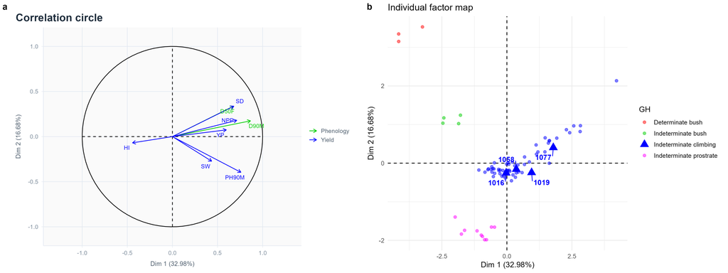

```
       eigenvalue percentage of variance cumulative percentage of variance
comp 1       2.12                  32.98                             32.98
comp 2       1.07                  16.68                             49.66
comp 3       1.01                  15.72                             65.38
```

```
           Morphology Phenology Yield  MFA
Morphology       1.00      0.08  0.21 0.74
Phenology        0.08      1.00  0.50 0.63
Yield            0.21      0.50  1.00 0.74
MFA              0.74      0.63  0.74 1.00
```

```
           Dim.1 Dim.2 Dim.3
Morphology  26.1  78.6  98.7
Phenology   33.5   7.9   0.2
Yield       40.4  13.5   1.0
```

```
            Dim1       Dim2 geno                     GH prom
1016 -0.02856421 -0.2541008 1016 Indeterminate climbing TRUE
1019  0.94991798 -0.2431245 1019 Indeterminate climbing TRUE
1058  0.36110484 -0.1580682 1058 Indeterminate climbing TRUE
1077  1.78457923  0.4039555 1077 Indeterminate climbing TRUE
```

# 6 Supplementary multivariate framework for mixed data

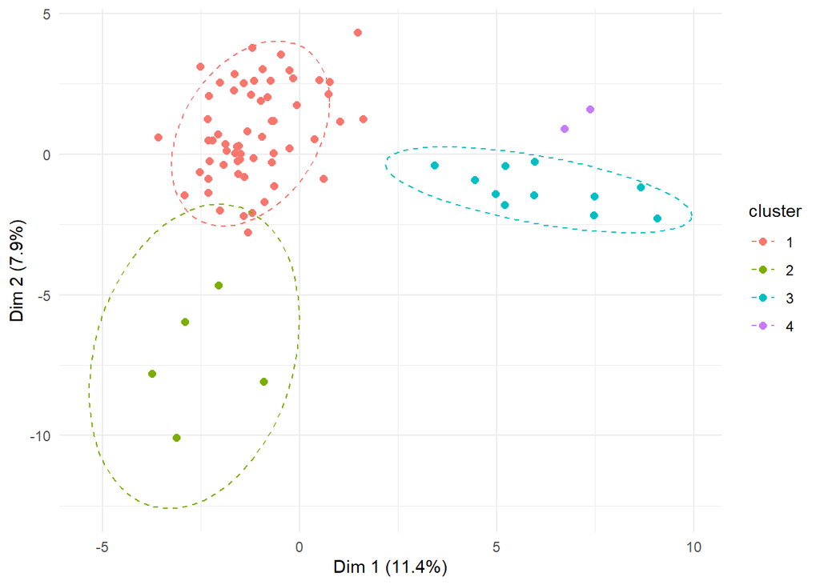

# 7 End